# Risk Factor Analysis

## Outcome Variable

**Outcome Variable:** wast_rec90d

## Predictor Variables

**Intervention Variable:** mbmi

**Adjustment Set:**

- arm
- W_mage
- meducyrs
- feducyrs
- single
- brthmon
- delta_W_mage
- delta_meducyrs
- delta_feducyrs
- delta_single
- delta_brthmon

## Stratifying Variables

The analysis was stratified on these variable(s):

- agecat
- studyid
- country

## Data Summary

| agecat | studyid | country | mbmi | wast_rec90d | n_cell | n |
| --- | --- | --- | --- | --- | --- | --- |
| 0-24 months | ki0047075b-MAL-ED | BANGLADESH | Normal weight | 0 | 28 | 122 |
| 0-24 months | ki0047075b-MAL-ED | BANGLADESH | Normal weight | 1 | 51 | 122 |
| 0-24 months | ki0047075b-MAL-ED | BANGLADESH | Underweight | 0 | 14 | 122 |
| 0-24 months | ki0047075b-MAL-ED | BANGLADESH | Underweight | 1 | 15 | 122 |
| 0-24 months | ki0047075b-MAL-ED | BANGLADESH | Overweight or Obese | 0 | 2 | 122 |
| 0-24 months | ki0047075b-MAL-ED | BANGLADESH | Overweight or Obese | 1 | 12 | 122 |
| 0-24 months | ki0047075b-MAL-ED | BRAZIL | Normal weight | 0 | 2 | 23 |
| 0-24 months | ki0047075b-MAL-ED | BRAZIL | Normal weight | 1 | 8 | 23 |
| 0-24 months | ki0047075b-MAL-ED | BRAZIL | Underweight | 0 | 0 | 23 |
| 0-24 months | ki0047075b-MAL-ED | BRAZIL | Underweight | 1 | 2 | 23 |
| 0-24 months | ki0047075b-MAL-ED | BRAZIL | Overweight or Obese | 0 | 4 | 23 |
| 0-24 months | ki0047075b-MAL-ED | BRAZIL | Overweight or Obese | 1 | 7 | 23 |
| 0-24 months | ki0047075b-MAL-ED | INDIA | Normal weight | 0 | 40 | 175 |
| 0-24 months | ki0047075b-MAL-ED | INDIA | Normal weight | 1 | 70 | 175 |
| 0-24 months | ki0047075b-MAL-ED | INDIA | Underweight | 0 | 22 | 175 |
| 0-24 months | ki0047075b-MAL-ED | INDIA | Underweight | 1 | 25 | 175 |
| 0-24 months | ki0047075b-MAL-ED | INDIA | Overweight or Obese | 0 | 8 | 175 |
| 0-24 months | ki0047075b-MAL-ED | INDIA | Overweight or Obese | 1 | 10 | 175 |
| 0-24 months | ki0047075b-MAL-ED | NEPAL | Normal weight | 0 | 17 | 93 |
| 0-24 months | ki0047075b-MAL-ED | NEPAL | Normal weight | 1 | 50 | 93 |
| 0-24 months | ki0047075b-MAL-ED | NEPAL | Underweight | 0 | 0 | 93 |
| 0-24 months | ki0047075b-MAL-ED | NEPAL | Underweight | 1 | 0 | 93 |
| 0-24 months | ki0047075b-MAL-ED | NEPAL | Overweight or Obese | 0 | 3 | 93 |
| 0-24 months | ki0047075b-MAL-ED | NEPAL | Overweight or Obese | 1 | 23 | 93 |
| 0-24 months | ki0047075b-MAL-ED | PERU | Normal weight | 0 | 4 | 34 |
| 0-24 months | ki0047075b-MAL-ED | PERU | Normal weight | 1 | 17 | 34 |
| 0-24 months | ki0047075b-MAL-ED | PERU | Underweight | 0 | 1 | 34 |
| 0-24 months | ki0047075b-MAL-ED | PERU | Underweight | 1 | 3 | 34 |
| 0-24 months | ki0047075b-MAL-ED | PERU | Overweight or Obese | 0 | 1 | 34 |
| 0-24 months | ki0047075b-MAL-ED | PERU | Overweight or Obese | 1 | 8 | 34 |

[output cut: 252 more lines]

The following strata were considered:

- agecat: 0-24 months, studyid: ki0047075b-MAL-ED, country: BANGLADESH
- agecat: 0-24 months, studyid: ki0047075b-MAL-ED, country: BRAZIL
- agecat: 0-24 months, studyid: ki0047075b-MAL-ED, country: INDIA
- agecat: 0-24 months, studyid: ki0047075b-MAL-ED, country: NEPAL
- agecat: 0-24 months, studyid: ki0047075b-MAL-ED, country: PERU
- agecat: 0-24 months, studyid: ki0047075b-MAL-ED, country: SOUTH AFRICA
- agecat: 0-24 months, studyid: ki0047075b-MAL-ED, country: TANZANIA, UNITED REPUBLIC OF
- agecat: 0-24 months, studyid: ki1000304b-SAS-CompFeed, country: INDIA
- agecat: 0-24 months, studyid: ki1017093-NIH-Birth, country: BANGLADESH
- agecat: 0-24 months, studyid: ki1017093b-PROVIDE, country: BANGLADESH
- agecat: 0-24 months, studyid: ki1017093c-NIH-Crypto, country: BANGLADESH
- agecat: 0-24 months, studyid: ki1066203-TanzaniaChild2, country: TANZANIA, UNITED REPUBLIC OF
- agecat: 0-24 months, studyid: ki1112895-iLiNS-Zinc, country: BURKINA FASO
- agecat: 0-24 months, studyid: ki1119695-PROBIT, country: BELARUS
- agecat: 0-24 months, studyid: ki1126311-ZVITAMBO, country: ZIMBABWE
- agecat: 0-24 months, studyid: ki1148112-LCNI-5, country: MALAWI
- agecat: 0-6 months, studyid: ki0047075b-MAL-ED, country: BANGLADESH
- agecat: 0-6 months, studyid: ki0047075b-MAL-ED, country: BRAZIL
- agecat: 0-6 months, studyid: ki0047075b-MAL-ED, country: INDIA
- agecat: 0-6 months, studyid: ki0047075b-MAL-ED, country: NEPAL
- agecat: 0-6 months, studyid: ki0047075b-MAL-ED, country: PERU
- agecat: 0-6 months, studyid: ki0047075b-MAL-ED, country: SOUTH AFRICA
- agecat: 0-6 months, studyid: ki0047075b-MAL-ED, country: TANZANIA, UNITED REPUBLIC OF
- agecat: 0-6 months, studyid: ki1000304b-SAS-CompFeed, country: INDIA
- agecat: 0-6 months, studyid: ki1017093-NIH-Birth, country: BANGLADESH
- agecat: 0-6 months, studyid: ki1017093b-PROVIDE, country: BANGLADESH
- agecat: 0-6 months, studyid: ki1017093c-NIH-Crypto, country: BANGLADESH
- agecat: 0-6 months, studyid: ki1066203-TanzaniaChild2, country: TANZANIA, UNITED REPUBLIC OF
- agecat: 0-6 months, studyid: ki1119695-PROBIT, country: BELARUS
- agecat: 0-6 months, studyid: ki1126311-ZVITAMBO, country: ZIMBABWE
- agecat: 0-6 months, studyid: ki1148112-LCNI-5, country: MALAWI
- agecat: 6-24 months, studyid: ki0047075b-MAL-ED, country: BANGLADESH
- agecat: 6-24 months, studyid: ki0047075b-MAL-ED, country: BRAZIL
- agecat: 6-24 months, studyid: ki0047075b-MAL-ED, country: INDIA
- agecat: 6-24 months, studyid: ki0047075b-MAL-ED, country: NEPAL
- agecat: 6-24 months, studyid: ki0047075b-MAL-ED, country: PERU
- agecat: 6-24 months, studyid: ki0047075b-MAL-ED, country: SOUTH AFRICA
- agecat: 6-24 months, studyid: ki0047075b-MAL-ED, country: TANZANIA, UNITED REPUBLIC OF
- agecat: 6-24 months, studyid: ki1000304b-SAS-CompFeed, country: INDIA
- agecat: 6-24 months, studyid: ki1017093-NIH-Birth, country: BANGLADESH
- agecat: 6-24 months, studyid: ki1017093b-PROVIDE, country: BANGLADESH
- agecat: 6-24 months, studyid: ki1017093c-NIH-Crypto, country: BANGLADESH
- agecat: 6-24 months, studyid: ki1066203-TanzaniaChild2, country: TANZANIA, UNITED REPUBLIC OF
- agecat: 6-24 months, studyid: ki1112895-iLiNS-Zinc, country: BURKINA FASO
- agecat: 6-24 months, studyid: ki1119695-PROBIT, country: BELARUS
- agecat: 6-24 months, studyid: ki1126311-ZVITAMBO, country: ZIMBABWE
- agecat: 6-24 months, studyid: ki1148112-LCNI-5, country: MALAWI

### Dropped Strata

Some strata were dropped due to rare outcomes:

- agecat: 0-24 months, studyid: ki0047075b-MAL-ED, country: BANGLADESH
- agecat: 0-24 months, studyid: ki0047075b-MAL-ED, country: BRAZIL
- agecat: 0-24 months, studyid: ki0047075b-MAL-ED, country: NEPAL
- agecat: 0-24 months, studyid: ki0047075b-MAL-ED, country: PERU
- agecat: 0-24 months, studyid: ki0047075b-MAL-ED, country: SOUTH AFRICA
- agecat: 0-24 months, studyid: ki0047075b-MAL-ED, country: TANZANIA, UNITED REPUBLIC OF
- agecat: 0-24 months, studyid: ki1112895-iLiNS-Zinc, country: BURKINA FASO
- agecat: 0-24 months, studyid: ki1148112-LCNI-5, country: MALAWI
- agecat: 0-6 months, studyid: ki0047075b-MAL-ED, country: BANGLADESH
- agecat: 0-6 months, studyid: ki0047075b-MAL-ED, country: BRAZIL
- agecat: 0-6 months, studyid: ki0047075b-MAL-ED, country: INDIA
- agecat: 0-6 months, studyid: ki0047075b-MAL-ED, country: NEPAL
- agecat: 0-6 months, studyid: ki0047075b-MAL-ED, country: PERU
- agecat: 0-6 months, studyid: ki0047075b-MAL-ED, country: SOUTH AFRICA
- agecat: 0-6 months, studyid: ki0047075b-MAL-ED, country: TANZANIA, UNITED REPUBLIC OF
- agecat: 0-6 months, studyid: ki1017093b-PROVIDE, country: BANGLADESH
- agecat: 0-6 months, studyid: ki1017093c-NIH-Crypto, country: BANGLADESH
- agecat: 0-6 months, studyid: ki1066203-TanzaniaChild2, country: TANZANIA, UNITED REPUBLIC OF
- agecat: 0-6 months, studyid: ki1148112-LCNI-5, country: MALAWI
- agecat: 6-24 months, studyid: ki0047075b-MAL-ED, country: BANGLADESH
- agecat: 6-24 months, studyid: ki0047075b-MAL-ED, country: BRAZIL
- agecat: 6-24 months, studyid: ki0047075b-MAL-ED, country: INDIA
- agecat: 6-24 months, studyid: ki0047075b-MAL-ED, country: NEPAL
- agecat: 6-24 months, studyid: ki0047075b-MAL-ED, country: PERU
- agecat: 6-24 months, studyid: ki0047075b-MAL-ED, country: SOUTH AFRICA
- agecat: 6-24 months, studyid: ki0047075b-MAL-ED, country: TANZANIA, UNITED REPUBLIC OF
- agecat: 6-24 months, studyid: ki1017093c-NIH-Crypto, country: BANGLADESH
- agecat: 6-24 months, studyid: ki1066203-TanzaniaChild2, country: TANZANIA, UNITED REPUBLIC OF
- agecat: 6-24 months, studyid: ki1112895-iLiNS-Zinc, country: BURKINA FASO
- agecat: 6-24 months, studyid: ki1119695-PROBIT, country: BELARUS
- agecat: 6-24 months, studyid: ki1148112-LCNI-5, country: MALAWI

## Methods Detail

We’re interested in the causal parameters $E[Y_a]$ for all values of $a \in \mathcal{A}$. These parameters represent the mean outcome if, possibly contrary to fact, we intervened to set all units to have $A=a$. Under the randomization and positivity assumptions, these are identified by the statistical parameters $\psi_a=E_W[E_{Y|A,W}(Y|A=a,W)]$. In addition, we’re interested in the mean of $Y$, $E[Y]$ under no intervention (the observed mean). We will estimate these parameters by using SuperLearner to fit the relevant likelihood factors – $E_{Y|A,W}(Y|A=a,W)$ and $p(A=a|W)$, and then updating our likelihood fit using a joint TMLE.

For unadjusted analyses ($W=\{\}$), initial likelihoods were estimated using Lrnr_glm to estimate the simple $E(Y|A)$ and Lrnr_mean to estimate $p(A)$. For adjusted analyses, a small library containing Lrnr_glmnet, Lrnr_xgboost, and Lrnr_mean was used.

Having estimated these parameters, we will then use the delta method to estimate relative risks and attributable risks relative to a prespecified baseline level of $A$.

# Results Detail

## Results Plots

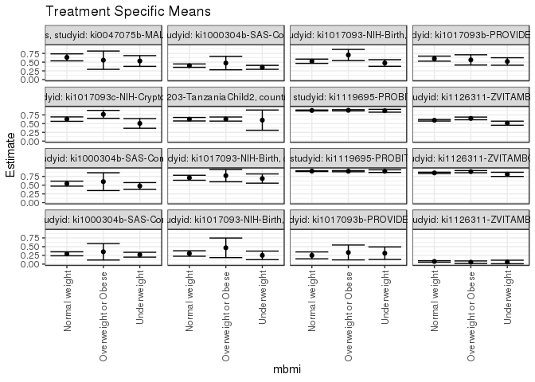

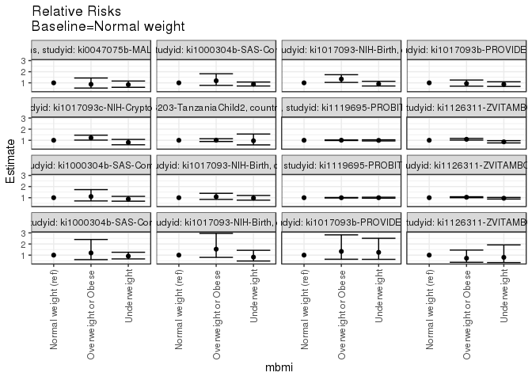

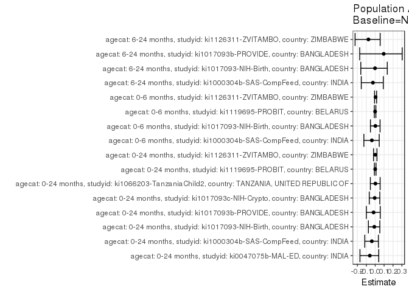

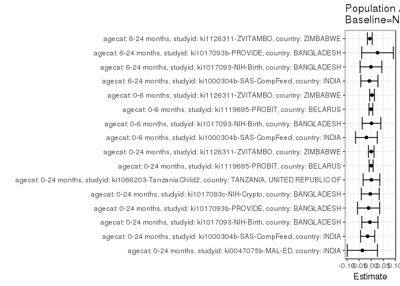

## Results Table

### Parameter: TSM

| agecat | studyid | country | intervention_level | baseline_level | estimate | ci_lower | ci_upper |
| --- | --- | --- | --- | --- | --- | --- | --- |
| 0-24 months | ki0047075b-MAL-ED | INDIA | Normal weight | NA | 0.6363636 | 0.5362335 | 0.7364938 |
| 0-24 months | ki0047075b-MAL-ED | INDIA | Underweight | NA | 0.5319149 | 0.3779503 | 0.6858794 |
| 0-24 months | ki0047075b-MAL-ED | INDIA | Overweight or Obese | NA | 0.5555556 | 0.2937267 | 0.8173844 |
| 0-24 months | ki1000304b-SAS-CompFeed | INDIA | Normal weight | NA | 0.3990046 | 0.3506899 | 0.4473193 |
| 0-24 months | ki1000304b-SAS-CompFeed | INDIA | Underweight | NA | 0.3501905 | 0.2934450 | 0.4069360 |
| 0-24 months | ki1000304b-SAS-CompFeed | INDIA | Overweight or Obese | NA | 0.4734399 | 0.2798429 | 0.6670369 |
| 0-24 months | ki1017093-NIH-Birth | BANGLADESH | Normal weight | NA | 0.5254556 | 0.4642681 | 0.5866431 |
| 0-24 months | ki1017093-NIH-Birth | BANGLADESH | Underweight | NA | 0.4746216 | 0.3794493 | 0.5697939 |
| 0-24 months | ki1017093-NIH-Birth | BANGLADESH | Overweight or Obese | NA | 0.7047639 | 0.5452427 | 0.8642850 |
| 0-24 months | ki1017093b-PROVIDE | BANGLADESH | Normal weight | NA | 0.6002369 | 0.5278287 | 0.6726451 |
| 0-24 months | ki1017093b-PROVIDE | BANGLADESH | Underweight | NA | 0.5185106 | 0.4113882 | 0.6256330 |
| 0-24 months | ki1017093b-PROVIDE | BANGLADESH | Overweight or Obese | NA | 0.5632733 | 0.4159966 | 0.7105499 |
| 0-24 months | ki1017093c-NIH-Crypto | BANGLADESH | Normal weight | NA | 0.6294089 | 0.5660664 | 0.6927514 |
| 0-24 months | ki1017093c-NIH-Crypto | BANGLADESH | Underweight | NA | 0.5064896 | 0.3670399 | 0.6459393 |
| 0-24 months | ki1017093c-NIH-Crypto | BANGLADESH | Overweight or Obese | NA | 0.7661807 | 0.6524289 | 0.8799325 |
| 0-24 months | ki1066203-TanzaniaChild2 | TANZANIA, UNITED REPUBLIC OF | Normal weight | NA | 0.6269430 | 0.5765029 | 0.6773831 |
| 0-24 months | ki1066203-TanzaniaChild2 | TANZANIA, UNITED REPUBLIC OF | Underweight | NA | 0.6000000 | 0.3102120 | 0.8897880 |
| 0-24 months | ki1066203-TanzaniaChild2 | TANZANIA, UNITED REPUBLIC OF | Overweight or Obese | NA | 0.6312292 | 0.5725732 | 0.6898853 |
| 0-24 months | ki1119695-PROBIT | BELARUS | Normal weight | NA | 0.8769834 | 0.8639877 | 0.8899791 |
| 0-24 months | ki1119695-PROBIT | BELARUS | Underweight | NA | 0.8691130 | 0.8279661 | 0.9102600 |
| 0-24 months | ki1119695-PROBIT | BELARUS | Overweight or Obese | NA | 0.8813284 | 0.8642628 | 0.8983940 |
| 0-24 months | ki1126311-ZVITAMBO | ZIMBABWE | Normal weight | NA | 0.5963873 | 0.5746088 | 0.6181659 |
| 0-24 months | ki1126311-ZVITAMBO | ZIMBABWE | Underweight | NA | 0.5127479 | 0.4540819 | 0.5714140 |
| 0-24 months | ki1126311-ZVITAMBO | ZIMBABWE | Overweight or Obese | NA | 0.6493666 | 0.6107111 | 0.6880222 |
| 0-6 months | ki1000304b-SAS-CompFeed | INDIA | Normal weight | NA | 0.5425532 | 0.4710034 | 0.6141030 |
| 0-6 months | ki1000304b-SAS-CompFeed | INDIA | Underweight | NA | 0.4757282 | 0.3780364 | 0.5734199 |
| 0-6 months | ki1000304b-SAS-CompFeed | INDIA | Overweight or Obese | NA | 0.6000000 | 0.3449982 | 0.8550017 |
| 0-6 months | ki1017093-NIH-Birth | BANGLADESH | Normal weight | NA | 0.7115385 | 0.6399635 | 0.7831134 |
| 0-6 months | ki1017093-NIH-Birth | BANGLADESH | Underweight | NA | 0.6888889 | 0.5565481 | 0.8212297 |
| 0-6 months | ki1017093-NIH-Birth | BANGLADESH | Overweight or Obese | NA | 0.7727273 | 0.5964259 | 0.9490287 |
| 0-6 months | ki1119695-PROBIT | BELARUS | Normal weight | NA | 0.9012517 | 0.8889436 | 0.9135598 |
| 0-6 months | ki1119695-PROBIT | BELARUS | Underweight | NA | 0.9009194 | 0.8628894 | 0.9389494 |
| 0-6 months | ki1119695-PROBIT | BELARUS | Overweight or Obese | NA | 0.8996180 | 0.8832486 | 0.9159875 |
| 0-6 months | ki1126311-ZVITAMBO | ZIMBABWE | Normal weight | NA | 0.8510339 | 0.8318190 | 0.8702488 |
| 0-6 months | ki1126311-ZVITAMBO | ZIMBABWE | Underweight | NA | 0.8092347 | 0.7495810 | 0.8688884 |
| 0-6 months | ki1126311-ZVITAMBO | ZIMBABWE | Overweight or Obese | NA | 0.8863291 | 0.8554838 | 0.9171744 |
| 6-24 months | ki1000304b-SAS-CompFeed | INDIA | Normal weight | NA | 0.2950192 | 0.2376229 | 0.3524154 |
| 6-24 months | ki1000304b-SAS-CompFeed | INDIA | Underweight | NA | 0.2687500 | 0.1996612 | 0.3378388 |
| 6-24 months | ki1000304b-SAS-CompFeed | INDIA | Overweight or Obese | NA | 0.3529412 | 0.1170851 | 0.5887972 |
| 6-24 months | ki1017093-NIH-Birth | BANGLADESH | Normal weight | NA | 0.3037037 | 0.2251033 | 0.3823041 |
| 6-24 months | ki1017093-NIH-Birth | BANGLADESH | Underweight | NA | 0.2500000 | 0.1270597 | 0.3729403 |
| 6-24 months | ki1017093-NIH-Birth | BANGLADESH | Overweight or Obese | NA | 0.4666667 | 0.1865148 | 0.7468185 |
| 6-24 months | ki1017093b-PROVIDE | BANGLADESH | Normal weight | NA | 0.2500000 | 0.1514093 | 0.3485907 |
| 6-24 months | ki1017093b-PROVIDE | BANGLADESH | Underweight | NA | 0.3125000 | 0.1324872 | 0.4925128 |
| 6-24 months | ki1017093b-PROVIDE | BANGLADESH | Overweight or Obese | NA | 0.3333333 | 0.1209556 | 0.5457111 |
| 6-24 months | ki1126311-ZVITAMBO | ZIMBABWE | Normal weight | NA | 0.0760697 | 0.0555576 | 0.0965819 |
| 6-24 months | ki1126311-ZVITAMBO | ZIMBABWE | Underweight | NA | 0.0609756 | 0.0103160 | 0.1116352 |
| 6-24 months | ki1126311-ZVITAMBO | ZIMBABWE | Overweight or Obese | NA | 0.0548780 | 0.0194551 | 0.0903010 |

### Parameter: E(Y)

| agecat | studyid | country | intervention_level | baseline_level | estimate | ci_lower | ci_upper |
| --- | --- | --- | --- | --- | --- | --- | --- |
| 0-24 months | ki0047075b-MAL-ED | INDIA | NA | NA | 0.6000000 | 0.5192868 | 0.6807132 |
| 0-24 months | ki1000304b-SAS-CompFeed | INDIA | NA | NA | 0.3844086 | 0.3477135 | 0.4211037 |
| 0-24 months | ki1017093-NIH-Birth | BANGLADESH | NA | NA | 0.5201900 | 0.4695846 | 0.5707955 |
| 0-24 months | ki1017093b-PROVIDE | BANGLADESH | NA | NA | 0.5894040 | 0.5323948 | 0.6464131 |
| 0-24 months | ki1017093c-NIH-Crypto | BANGLADESH | NA | NA | 0.6258065 | 0.5718723 | 0.6797406 |
| 0-24 months | ki1066203-TanzaniaChild2 | TANZANIA, UNITED REPUBLIC OF | NA | NA | 0.6282051 | 0.5902579 | 0.6661523 |
| 0-24 months | ki1119695-PROBIT | BELARUS | NA | NA | 0.8768959 | 0.8667536 | 0.8870382 |
| 0-24 months | ki1126311-ZVITAMBO | ZIMBABWE | NA | NA | 0.5967742 | 0.5781484 | 0.6154000 |
| 0-6 months | ki1000304b-SAS-CompFeed | INDIA | NA | NA | 0.5228758 | 0.4664267 | 0.5793250 |
| 0-6 months | ki1017093-NIH-Birth | BANGLADESH | NA | NA | 0.7130045 | 0.6535890 | 0.7724200 |
| 0-6 months | ki1119695-PROBIT | BELARUS | NA | NA | 0.9001049 | 0.8905121 | 0.9096977 |
| 0-6 months | ki1126311-ZVITAMBO | ZIMBABWE | NA | NA | 0.8546674 | 0.8383989 | 0.8709359 |
| 6-24 months | ki1000304b-SAS-CompFeed | INDIA | NA | NA | 0.2876712 | 0.2441703 | 0.3311721 |
| 6-24 months | ki1017093-NIH-Birth | BANGLADESH | NA | NA | 0.3030303 | 0.2377927 | 0.3682679 |
| 6-24 months | ki1017093b-PROVIDE | BANGLADESH | NA | NA | 0.2764228 | 0.1950773 | 0.3577682 |
| 6-24 months | ki1126311-ZVITAMBO | ZIMBABWE | NA | NA | 0.0706956 | 0.0538314 | 0.0875597 |

### Parameter: RR

| agecat | studyid | country | intervention_level | baseline_level | estimate | ci_lower | ci_upper |
| --- | --- | --- | --- | --- | --- | --- | --- |
| 0-24 months | ki0047075b-MAL-ED | INDIA | Normal weight | Normal weight | 1.0000000 | 1.0000000 | 1.0000000 |
| 0-24 months | ki0047075b-MAL-ED | INDIA | Underweight | Normal weight | 0.8358663 | 0.6012549 | 1.1620235 |
| 0-24 months | ki0047075b-MAL-ED | INDIA | Overweight or Obese | Normal weight | 0.8730159 | 0.5311732 | 1.4348554 |
| 0-24 months | ki1000304b-SAS-CompFeed | INDIA | Normal weight | Normal weight | 1.0000000 | 1.0000000 | 1.0000000 |
| 0-24 months | ki1000304b-SAS-CompFeed | INDIA | Underweight | Normal weight | 0.8776603 | 0.7168726 | 1.0745111 |
| 0-24 months | ki1000304b-SAS-CompFeed | INDIA | Overweight or Obese | Normal weight | 1.1865526 | 0.7746535 | 1.8174669 |
| 0-24 months | ki1017093-NIH-Birth | BANGLADESH | Normal weight | Normal weight | 1.0000000 | 1.0000000 | 1.0000000 |
| 0-24 months | ki1017093-NIH-Birth | BANGLADESH | Underweight | Normal weight | 0.9032573 | 0.7162644 | 1.1390679 |
| 0-24 months | ki1017093-NIH-Birth | BANGLADESH | Overweight or Obese | Normal weight | 1.3412435 | 1.0395431 | 1.7305046 |
| 0-24 months | ki1017093b-PROVIDE | BANGLADESH | Normal weight | Normal weight | 1.0000000 | 1.0000000 | 1.0000000 |
| 0-24 months | ki1017093b-PROVIDE | BANGLADESH | Underweight | Normal weight | 0.8638433 | 0.6799701 | 1.0974383 |
| 0-24 months | ki1017093b-PROVIDE | BANGLADESH | Overweight or Obese | Normal weight | 0.9384183 | 0.7036510 | 1.2515136 |
| 0-24 months | ki1017093c-NIH-Crypto | BANGLADESH | Normal weight | Normal weight | 1.0000000 | 1.0000000 | 1.0000000 |
| 0-24 months | ki1017093c-NIH-Crypto | BANGLADESH | Underweight | Normal weight | 0.8047068 | 0.6001883 | 1.0789164 |
| 0-24 months | ki1017093c-NIH-Crypto | BANGLADESH | Overweight or Obese | Normal weight | 1.2173020 | 1.0174352 | 1.4564311 |
| 0-24 months | ki1066203-TanzaniaChild2 | TANZANIA, UNITED REPUBLIC OF | Normal weight | Normal weight | 1.0000000 | 1.0000000 | 1.0000000 |
| 0-24 months | ki1066203-TanzaniaChild2 | TANZANIA, UNITED REPUBLIC OF | Underweight | Normal weight | 0.9570248 | 0.5865140 | 1.5615934 |
| 0-24 months | ki1066203-TanzaniaChild2 | TANZANIA, UNITED REPUBLIC OF | Overweight or Obese | Normal weight | 1.0068367 | 0.8903835 | 1.1385209 |
| 0-24 months | ki1119695-PROBIT | BELARUS | Normal weight | Normal weight | 1.0000000 | 1.0000000 | 1.0000000 |
| 0-24 months | ki1119695-PROBIT | BELARUS | Underweight | Normal weight | 0.9910256 | 0.9430609 | 1.0414299 |
| 0-24 months | ki1119695-PROBIT | BELARUS | Overweight or Obese | Normal weight | 1.0049545 | 0.9807477 | 1.0297587 |
| 0-24 months | ki1126311-ZVITAMBO | ZIMBABWE | Normal weight | Normal weight | 1.0000000 | 1.0000000 | 1.0000000 |
| 0-24 months | ki1126311-ZVITAMBO | ZIMBABWE | Underweight | Normal weight | 0.8597566 | 0.7625101 | 0.9694054 |
| 0-24 months | ki1126311-ZVITAMBO | ZIMBABWE | Overweight or Obese | Normal weight | 1.0888338 | 1.0154759 | 1.1674910 |
| 0-6 months | ki1000304b-SAS-CompFeed | INDIA | Normal weight | Normal weight | 1.0000000 | 1.0000000 | 1.0000000 |
| 0-6 months | ki1000304b-SAS-CompFeed | INDIA | Underweight | Normal weight | 0.8768323 | 0.6869472 | 1.1192052 |
| 0-6 months | ki1000304b-SAS-CompFeed | INDIA | Overweight or Obese | Normal weight | 1.1058823 | 0.7086812 | 1.7257065 |
| 0-6 months | ki1017093-NIH-Birth | BANGLADESH | Normal weight | Normal weight | 1.0000000 | 1.0000000 | 1.0000000 |
| 0-6 months | ki1017093-NIH-Birth | BANGLADESH | Underweight | Normal weight | 0.9681682 | 0.7794242 | 1.2026180 |
| 0-6 months | ki1017093-NIH-Birth | BANGLADESH | Overweight or Obese | Normal weight | 1.0859951 | 0.8463273 | 1.3935333 |
| 0-6 months | ki1119695-PROBIT | BELARUS | Normal weight | Normal weight | 1.0000000 | 1.0000000 | 1.0000000 |
| 0-6 months | ki1119695-PROBIT | BELARUS | Underweight | Normal weight | 0.9996313 | 0.9562503 | 1.0449803 |
| 0-6 months | ki1119695-PROBIT | BELARUS | Overweight or Obese | Normal weight | 0.9981873 | 0.9757370 | 1.0211542 |
| 0-6 months | ki1126311-ZVITAMBO | ZIMBABWE | Normal weight | Normal weight | 1.0000000 | 1.0000000 | 1.0000000 |
| 0-6 months | ki1126311-ZVITAMBO | ZIMBABWE | Underweight | Normal weight | 0.9508843 | 0.8803371 | 1.0270849 |
| 0-6 months | ki1126311-ZVITAMBO | ZIMBABWE | Overweight or Obese | Normal weight | 1.0414734 | 0.9991564 | 1.0855826 |
| 6-24 months | ki1000304b-SAS-CompFeed | INDIA | Normal weight | Normal weight | 1.0000000 | 1.0000000 | 1.0000000 |
| 6-24 months | ki1000304b-SAS-CompFeed | INDIA | Underweight | Normal weight | 0.9109578 | 0.6599115 | 1.2575081 |
| 6-24 months | ki1000304b-SAS-CompFeed | INDIA | Overweight or Obese | Normal weight | 1.1963331 | 0.5964601 | 2.3995113 |
| 6-24 months | ki1017093-NIH-Birth | BANGLADESH | Normal weight | Normal weight | 1.0000000 | 1.0000000 | 1.0000000 |
| 6-24 months | ki1017093-NIH-Birth | BANGLADESH | Underweight | Normal weight | 0.8231707 | 0.4720661 | 1.4354135 |
| 6-24 months | ki1017093-NIH-Birth | BANGLADESH | Overweight or Obese | Normal weight | 1.5365854 | 0.7988788 | 2.9555102 |
| 6-24 months | ki1017093b-PROVIDE | BANGLADESH | Normal weight | Normal weight | 1.0000000 | 1.0000000 | 1.0000000 |
| 6-24 months | ki1017093b-PROVIDE | BANGLADESH | Underweight | Normal weight | 1.2500000 | 0.6218966 | 2.5124757 |
| 6-24 months | ki1017093b-PROVIDE | BANGLADESH | Overweight or Obese | Normal weight | 1.3333333 | 0.6302141 | 2.8209109 |
| 6-24 months | ki1126311-ZVITAMBO | ZIMBABWE | Normal weight | Normal weight | 1.0000000 | 1.0000000 | 1.0000000 |
| 6-24 months | ki1126311-ZVITAMBO | ZIMBABWE | Underweight | Normal weight | 0.8015752 | 0.3346533 | 1.9199653 |
| 6-24 months | ki1126311-ZVITAMBO | ZIMBABWE | Overweight or Obese | Normal weight | 0.7214177 | 0.3584089 | 1.4520942 |

### Parameter: PAR

| agecat | studyid | country | intervention_level | baseline_level | estimate | ci_lower | ci_upper |
| --- | --- | --- | --- | --- | --- | --- | --- |
| 0-24 months | ki0047075b-MAL-ED | INDIA | Normal weight | NA | -0.0363636 | -0.0990902 | 0.0263629 |
| 0-24 months | ki1000304b-SAS-CompFeed | INDIA | Normal weight | NA | -0.0145960 | -0.0439540 | 0.0147620 |
| 0-24 months | ki1017093-NIH-Birth | BANGLADESH | Normal weight | NA | -0.0052656 | -0.0386813 | 0.0281502 |
| 0-24 months | ki1017093b-PROVIDE | BANGLADESH | Normal weight | NA | -0.0108329 | -0.0567524 | 0.0350865 |
| 0-24 months | ki1017093c-NIH-Crypto | BANGLADESH | Normal weight | NA | -0.0036025 | -0.0407338 | 0.0335289 |
| 0-24 months | ki1066203-TanzaniaChild2 | TANZANIA, UNITED REPUBLIC OF | Normal weight | NA | 0.0012621 | -0.0331813 | 0.0357056 |
| 0-24 months | ki1119695-PROBIT | BELARUS | Normal weight | NA | -0.0000876 | -0.0083183 | 0.0081432 |
| 0-24 months | ki1126311-ZVITAMBO | ZIMBABWE | Normal weight | NA | 0.0003869 | -0.0111975 | 0.0119712 |
| 0-6 months | ki1000304b-SAS-CompFeed | INDIA | Normal weight | NA | -0.0196774 | -0.0646129 | 0.0252582 |
| 0-6 months | ki1017093-NIH-Birth | BANGLADESH | Normal weight | NA | 0.0014660 | -0.0370775 | 0.0400096 |
| 0-6 months | ki1119695-PROBIT | BELARUS | Normal weight | NA | -0.0011468 | -0.0090365 | 0.0067429 |
| 0-6 months | ki1126311-ZVITAMBO | ZIMBABWE | Normal weight | NA | 0.0036335 | -0.0063292 | 0.0135963 |
| 6-24 months | ki1000304b-SAS-CompFeed | INDIA | Normal weight | NA | -0.0073479 | -0.0428532 | 0.0281574 |
| 6-24 months | ki1017093-NIH-Birth | BANGLADESH | Normal weight | NA | -0.0006734 | -0.0456215 | 0.0442747 |
| 6-24 months | ki1017093b-PROVIDE | BANGLADESH | Normal weight | NA | 0.0264228 | -0.0392338 | 0.0920793 |
| 6-24 months | ki1126311-ZVITAMBO | ZIMBABWE | Normal weight | NA | -0.0053742 | -0.0153652 | 0.0046169 |

### Parameter: PAF

| agecat | studyid | country | intervention_level | baseline_level | estimate | ci_lower | ci_upper |
| --- | --- | --- | --- | --- | --- | --- | --- |
| 0-24 months | ki0047075b-MAL-ED | INDIA | Normal weight | NA | -0.0606061 | -0.1712012 | 0.0395457 |
| 0-24 months | ki1000304b-SAS-CompFeed | INDIA | Normal weight | NA | -0.0379700 | -0.1170863 | 0.0355430 |
| 0-24 months | ki1017093-NIH-Birth | BANGLADESH | Normal weight | NA | -0.0101224 | -0.0764340 | 0.0521042 |
| 0-24 months | ki1017093b-PROVIDE | BANGLADESH | Normal weight | NA | -0.0183795 | -0.0994096 | 0.0566785 |
| 0-24 months | ki1017093c-NIH-Crypto | BANGLADESH | Normal weight | NA | -0.0057565 | -0.0669136 | 0.0518950 |
| 0-24 months | ki1066203-TanzaniaChild2 | TANZANIA, UNITED REPUBLIC OF | Normal weight | NA | 0.0020091 | -0.0543494 | 0.0553551 |
| 0-24 months | ki1119695-PROBIT | BELARUS | Normal weight | NA | -0.0000998 | -0.0095302 | 0.0092425 |
| 0-24 months | ki1126311-ZVITAMBO | ZIMBABWE | Normal weight | NA | 0.0006483 | -0.0189528 | 0.0198723 |
| 0-6 months | ki1000304b-SAS-CompFeed | INDIA | Normal weight | NA | -0.0376330 | -0.1274107 | 0.0449956 |
| 0-6 months | ki1017093-NIH-Birth | BANGLADESH | Normal weight | NA | 0.0020561 | -0.0534973 | 0.0546801 |
| 0-6 months | ki1119695-PROBIT | BELARUS | Normal weight | NA | -0.0012741 | -0.0100781 | 0.0074532 |
| 0-6 months | ki1126311-ZVITAMBO | ZIMBABWE | Normal weight | NA | 0.0042514 | -0.0074756 | 0.0158419 |
| 6-24 months | ki1000304b-SAS-CompFeed | INDIA | Normal weight | NA | -0.0255428 | -0.1565687 | 0.0906394 |
| 6-24 months | ki1017093-NIH-Birth | BANGLADESH | Normal weight | NA | -0.0022222 | -0.1620994 | 0.1356597 |
| 6-24 months | ki1017093b-PROVIDE | BANGLADESH | Normal weight | NA | 0.0955882 | -0.1740688 | 0.3033111 |
| 6-24 months | ki1126311-ZVITAMBO | ZIMBABWE | Normal weight | NA | -0.0760186 | -0.2261275 | 0.0557131 |